# Principal Component Analysis Using Python - The Examples of Wine and Breast Data

**統計四 410878048 葉于廷**

```python
# packages
import numpy as np
import pandas as pd
import seaborn as sns
import matplotlib.pyplot as plt
from mpl_toolkits import mplot3d
from sklearn.decomposition import PCA
from sklearn.preprocessing import StandardScaler
from numpy.linalg import eig
import warnings
# ignore all warnings
warnings.filterwarnings("ignore")
```

## Introduction

Principal Component Analysis is a techinique dealing with multivariate data by reducing the numbers of original variables. And these new variables are called principal components, which are the linear combinations of the original variables. The goal of PCA is to retain as much of the original variance as possible while reducing the dimensions. For example, PCA can be applied to wine and breast cancer data and identify important features.

## Methods

1. Linear correlation of original variables - By drawing heat map, we observe the correlation between variables and determine whether some variables have strong or weak relations.
2. Range of variables - Before the PCA, we can decide if standardization is needed.
3. Tranformation results - By scree plot and pareto plot, we can evaluate and decide the number of principal components after PCA.
4. Sources of principal component - We examine correlation between original variables and principal components.
5. Discrimation of principal components - By creating 2d and 3d scatter plot with labeled groups, we can determine whether observations can be classified based on principal components.

### Function of PCA

For simplifying the code block, I write two functions. One is for report and graph after PCA, and the other is for creating a 3d scatter plot in assigned angle.

```python
def pca_report(cov_data, standardization, variables, numbers, case):

    # standardize data
    if standardization == True:
        scaler = StandardScaler()
        data = scaler.fit_transform(cov_data)
    else:
        data = cov_data

    pca = PCA()
    pca.fit(data)
    explained_variances = pca.explained_variance_[:numbers]
    tick_of_pc = ['PC' + str(x) for x in range(1, len(explained_variances) + 1)]

    if case == 1:
        # create figure and axes
        fig, [ax1, ax2] = plt.subplots(nrows=1, ncols=2, figsize=(13, 4))

        # scree plot
        ax1.plot(range(1, len(explained_variances) + 1), explained_variances, marker='o')
        ax1.set_title('Scree Plot')
        ax1.set_xlabel('Principal Component')
        ax1.set_ylabel('Explained Variance Ratio')

        # Perato Plot
        # calculate cumulative sum and percentage
        cumulative_variances = np.cumsum(explained_variances)
        percentage = [x/sum(explained_variances)*100 for x in cumulative_variances]
        # plot bar chart
        color1 = "blue"
        ax2.bar(tick_of_pc, explained_variances, color=color1, alpha=0.5)
        ax2.set_xlabel('The Number of Principal Components')
        ax2.set_ylabel('Explained Variance', color=color1)
        ax2.tick_params(axis='y', color=color1)
        # create secondary y-axis
        ax3 = ax2.twinx()
        # plot cumulative percentage line chart
        ax3.plot(tick_of_pc, percentage, color='purple', marker='o', alpha = 0.5)
        ax3.set_ylabel('Cumulative Percentage (%)', color='purple')
        ax3.tick_params(axis='y', labelcolor='purple')
        # set title
        ax2.set_title('Pareto Plot')
        return plt

    if case == 2:
        # Create dataframe with variable names and PCA coefficients
        pca_df = pd.DataFrame(pca.components_[:numbers, :].T, columns=tick_of_pc)
        pca_df.index = variables

        # Round down to 2 decimal places
        pca_df = pca_df.round(2)

        # Add cumulative proportion and explained variance at the last two rows
        cumulative_proportion = np.cumsum(pca.explained_variance_ratio_[:numbers]) * 100
        explained_variance = pca.explained_variance_[:numbers]

        pca_df.loc['Cumulative Proportion(%)'] = cumulative_proportion.round(2)
        pca_df.loc['Explained Variance'] = explained_variance.round(2)
        return pca_df

    if case == 3:
        # tranfrom data
        tranformed_data = pd.DataFrame(pca.transform(data)[:, :numbers], columns = tick_of_pc)
        return tranformed_data

def draw_3d(tranformed_data, group, angel1, angel2, label):
    fig = plt.figure(figsize=(12,6))
    ax = fig.add_subplot(111, projection='3d')
    ax.view_init(angel1, angel2)
    for i in  tranformed_data[group].unique():
        draw_data = tranformed_data[tranformed_data[group] == i]
        x = draw_data.PC1
        y = draw_data.PC2
        z = draw_data.PC3
        ax.scatter(x, y, z, s = 40)
    ax.set_xlabel('P1')
    ax.set_ylabel('P2')
    ax.set_zlabel('P3', labelpad=-5)
    ax.set_title(label)
    plt.legend(tranformed_data[group].unique(), loc=(0.8, 0.7), fontsize = 10)
    plt.show()
```

## Wine data introduction

The data is the results of a chemical analysis of wines grown in the same region in Italy by three different cultivators. There are thirteen different measurements taken for different constituents found in the three types of wine.

```python
data = pd.read_excel("wine.xlsx")
data.head()
```

|  | Alcohol | Malic_Acid | Ash | Ash_Alcanity | Magnesium | Total_Phenols | Flavanoids | Nonflavanoid_Phenols | Proanthocyanins | Color_Intensity | Hue | OD280 | Proline | Customer_Segment |
| --- | --- | --- | --- | --- | --- | --- | --- | --- | --- | --- | --- | --- | --- | --- |
| 0 | 14.23 | 1.71 | 2.43 | 15.6 | 127 | 2.80 | 3.06 | 0.28 | 2.29 | 5.64 | 1.04 | 3.92 | 1065 | 1 |
| 1 | 13.20 | 1.78 | 2.14 | 11.2 | 100 | 2.65 | 2.76 | 0.26 | 1.28 | 4.38 | 1.05 | 3.40 | 1050 | 1 |
| 2 | 13.16 | 2.36 | 2.67 | 18.6 | 101 | 2.80 | 3.24 | 0.30 | 2.81 | 5.68 | 1.03 | 3.17 | 1185 | 1 |
| 3 | 14.37 | 1.95 | 2.50 | 16.8 | 113 | 3.85 | 3.49 | 0.24 | 2.18 | 7.80 | 0.86 | 3.45 | 1480 | 1 |
| 4 | 13.24 | 2.59 | 2.87 | 21.0 | 118 | 2.80 | 2.69 | 0.39 | 1.82 | 4.32 | 1.04 | 2.93 | 735 | 1 |

### Linear correlation of original variables

- Strong positive correlation: Flavanoids and Total_Phenols (0.86), OD280 and Flavanoids (0.79), OD280 and Total_Phenols(0.7)
- Mild weak negative correlation: Nonflavanoid_Phenols and Flavanoids (-0.54), Hue and Malic_Acid (-0.56), Hue and Color_Intensity (-0.52), OD280 and Nonflavanoid_Phenols (-0.5)

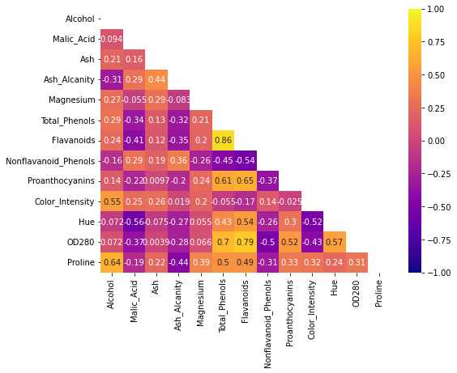

```python
# Create correlation matrix - Get Numerical Data
variables = ["Alcohol", "Malic_Acid", "Ash", "Ash_Alcanity", "Magnesium", "Total_Phenols", "Flavanoids", "Nonflavanoid_Phenols", "Proanthocyanins", "Color_Intensity", "Hue", "OD280", "Proline"]
cov_data = data[variables]
cov_corr = cov_data.corr()
# figure size
fig, ax = plt.subplots(figsize=(8,6))
# Set up mask to only show lower triangle
mask = np.zeros_like(cov_corr, dtype=np.bool)
mask[np.triu_indices_from(mask)] = True
# Plot heatmap
sns.heatmap(cov_corr, mask = mask, annot=True, cmap='plasma', square = False, vmin=-1, vmax=1)
plt.show()
```

### Range of variables

- Before standarization, the variable, proline, has a relatively larger range. This would have a great impact on principal components. We hope that every variables can contribute to PC, so standardization is recommended.
- After standardization, all data appears to have a similar range.

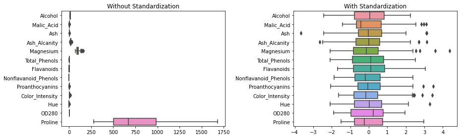

```python
fig, ax = plt.subplots(figsize=(13, 4))

# box plot without standardization
plt.subplot(1, 2, 1)
sns.boxplot(data= cov_data, orient='horizontal')
plt.title('Without Standardization')

# box plot with standardization
plt.subplot(1, 2, 2)
sns.boxplot(data=(cov_data - cov_data.mean()) / cov_data.std(), orient='horizontal')
plt.title('With Standardization')

# show plot
plt.tight_layout()
plt.show()
```

### Tranformation results

From scree plot and pareto plot, I decide to retain four principal components. For one thing, the scree plot shows a smooth curve after the fourth principal component. Additionally, the cumulative variance of four principal components is relatively high at 70 %.

```
<module 'matplotlib.pyplot' from 'c:\\Users\\user\\AppData\\Local\\Programs\\Python\\Python310\\lib\\site-packages\\matplotlib\\pyplot.py'>
```

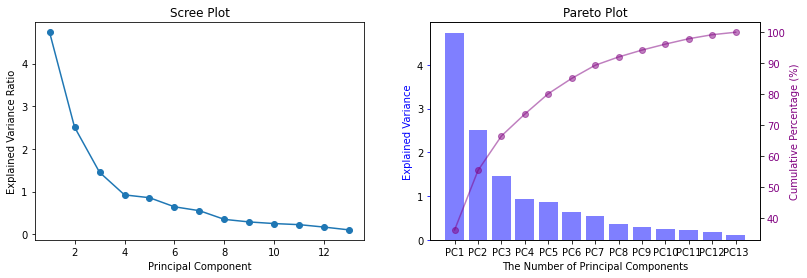

```python
pca_report(cov_data, standardization=1, variables = variables, numbers = 13, case = 1)
```

### Sources of principal component

Here are the main original variables that influence the principal component.

- 1st PC: Total_Phenols, Flavanoids, OD280
- 2nd PC: Color_Intensity, Alcohol, Proline
- 3rd PC: Ash, Ash_Alcanity
- 4th PC: Malic_Acid, Proanthocyanins, Hue

Displaying all primary sources of principal components, I discover that the principal components almost includes all original variables. In addition, the variables that are highly correlated are easily grouped in the same PC. For example, heapmap shows Flavanoids and Total_Phenols are high positively correlated and they are the main contribution of 1st PC.

```python
pca_report(cov_data, standardization=1, variables = variables, numbers = 13, case = 2)
```

|  | PC1 | PC2 | PC3 | PC4 | PC5 | PC6 | PC7 | PC8 | PC9 | PC10 | PC11 | PC12 | PC13 |
| --- | --- | --- | --- | --- | --- | --- | --- | --- | --- | --- | --- | --- | --- |
| Alcohol | 0.14 | -0.48 | -0.21 | -0.02 | -0.27 | -0.21 | -0.06 | -0.40 | 0.51 | 0.21 | -0.23 | -0.27 | 0.01 |
| Malic_Acid | -0.25 | -0.22 | 0.09 | 0.54 | 0.04 | -0.54 | 0.42 | -0.07 | -0.08 | -0.31 | 0.08 | 0.12 | 0.03 |
| Ash | -0.00 | -0.32 | 0.63 | -0.21 | -0.14 | -0.15 | -0.15 | 0.17 | -0.31 | -0.03 | -0.50 | -0.05 | -0.14 |
| Ash_Alcanity | -0.24 | 0.01 | 0.61 | 0.06 | 0.07 | 0.10 | -0.29 | -0.43 | 0.20 | 0.05 | 0.48 | -0.06 | 0.09 |
| Magnesium | 0.14 | -0.30 | 0.13 | -0.35 | 0.73 | -0.04 | 0.32 | 0.16 | 0.27 | 0.07 | 0.07 | 0.06 | 0.06 |
| Total_Phenols | 0.39 | -0.07 | 0.15 | 0.20 | -0.15 | 0.08 | -0.03 | 0.41 | 0.29 | -0.32 | 0.30 | -0.30 | -0.46 |
| Flavanoids | 0.42 | 0.00 | 0.15 | 0.15 | -0.11 | 0.02 | -0.06 | 0.19 | 0.05 | -0.16 | -0.03 | -0.04 | 0.83 |
| Nonflavanoid_Phenols | -0.30 | -0.03 | 0.17 | -0.20 | -0.50 | 0.26 | 0.60 | 0.23 | 0.20 | 0.22 | 0.12 | 0.04 | 0.11 |
| Proanthocyanins | 0.31 | -0.04 | 0.15 | 0.40 | 0.14 | 0.53 | 0.37 | -0.37 | -0.21 | 0.13 | -0.24 | -0.10 | -0.12 |
| Color_Intensity | -0.09 | -0.53 | -0.14 | 0.07 | -0.08 | 0.42 | -0.23 | 0.03 | 0.06 | -0.29 | 0.03 | 0.60 | -0.01 |
| Hue | 0.30 | 0.28 | 0.09 | -0.43 | -0.17 | -0.11 | 0.23 | -0.44 | 0.09 | -0.52 | -0.05 | 0.26 | -0.09 |
| OD280 | 0.38 | 0.16 | 0.17 | 0.18 | -0.10 | -0.27 | -0.04 | 0.08 | 0.14 | 0.52 | 0.05 | 0.60 | -0.16 |
| Proline | 0.29 | -0.36 | -0.13 | -0.23 | -0.16 | -0.12 | 0.08 | -0.12 | -0.58 | 0.16 | 0.54 | -0.08 | 0.01 |
| Cumulative Proportion(%) | 36.20 | 55.41 | 66.53 | 73.60 | 80.16 | 85.10 | 89.34 | 92.02 | 94.24 | 96.17 | 97.91 | 99.20 | 100.00 |
| Explained Variance | 4.73 | 2.51 | 1.45 | 0.92 | 0.86 | 0.65 | 0.55 | 0.35 | 0.29 | 0.25 | 0.23 | 0.17 | 0.10 |

### Discrimation of principal components

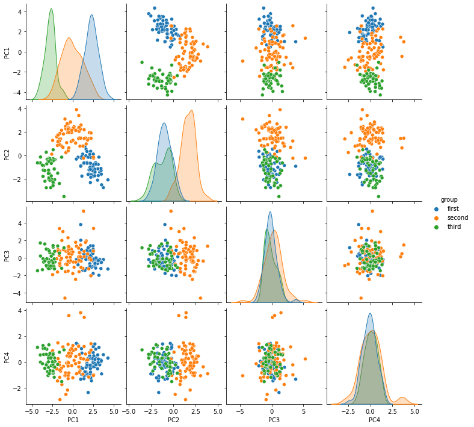

```python
tranformed_data = pca_report(cov_data, standardization=1, variables = variables, numbers = 13, case = 3).iloc[:, :4]
tranformed_data["group"] = np.where(data["Customer_Segment"] == 1, "first", np.where(data["Customer_Segment"] == 2, "second", "third"))
# Use the pairplot function to display a scatter plot of all variables in a square plot
sns.pairplot(tranformed_data, hue = "group")
tranformed_data.to_excel("transformed_data.xlsx")
```

- 3d scatter plot: showing three pcs altogether provides a clear seperation in space. Most dots are around 0 at z-axis, which shows p1 and p2 could be more effective classifiers. Then, when we view it in different angle. The scatter plot gets more like a two dimensions which reduces the effect of p3 and emphasizes on p2 and p1. This confirms the group can be distinguished well by the two.

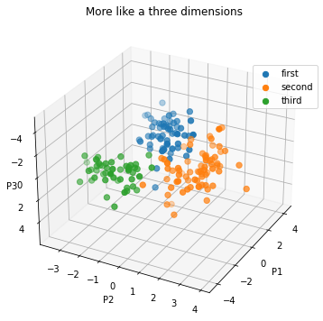

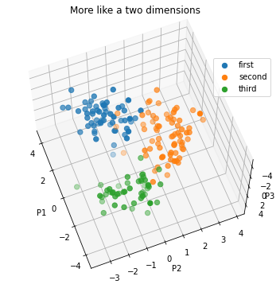

```python
draw_3d(tranformed_data, "group", -152, -28, "More like a three dimensions")
draw_3d(tranformed_data, "group", -117, 21, "More like a two dimensions")
```

### Breast Cancer Data Introduction

Features are computed from a digitized image of a fine needle aspirate (FNA) of a breast mass. They describe characteristics of the cell nuclei present in the image.

```python
from sklearn.datasets import load_breast_cancer

# Load the breast cancer dataset
breast_data = pd.DataFrame(load_breast_cancer().data, columns= load_breast_cancer().feature_names)

# Add the target variable as a column to the dataframe
breast_data['target'] = load_breast_cancer().target
```

### Linear correlation of original variables

The heatmap indcates most of those variables are positively correlated because a great many cells are nearly yellow colors.

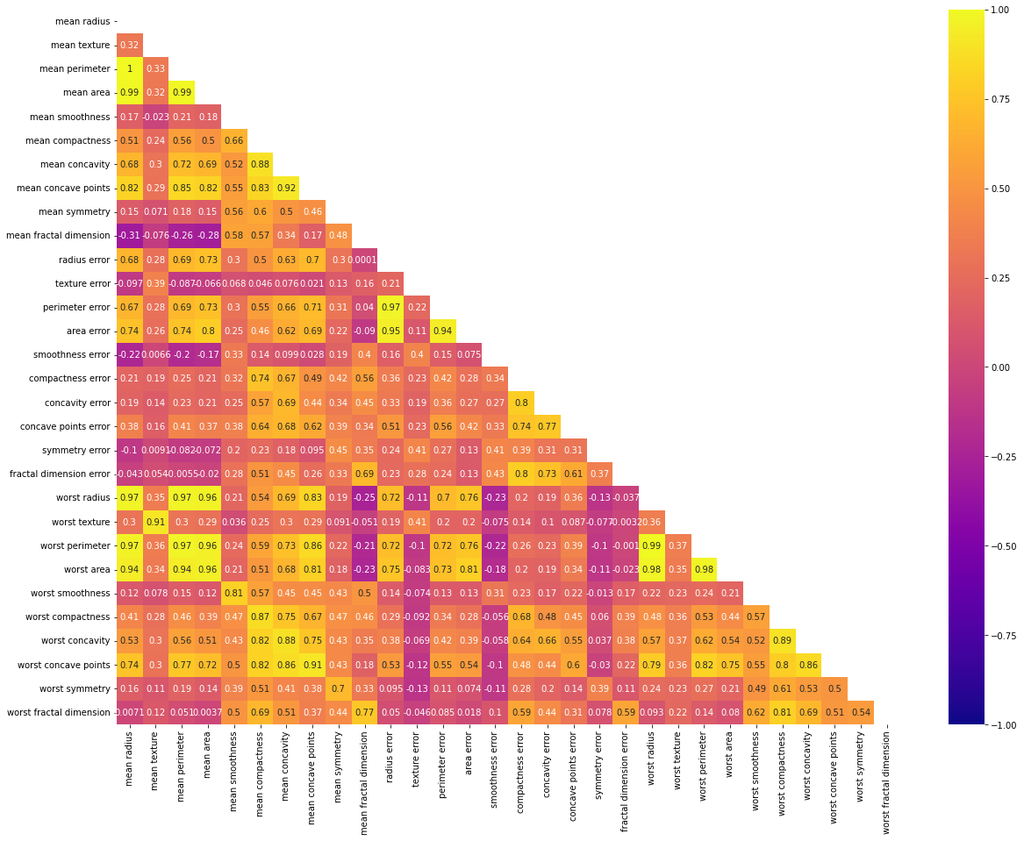

```python
# Create correlation matrix - Get Numerical Data
numeric_cols = [x for x in breast_data.columns if x != "target"]
cov_data = breast_data[numeric_cols]
cov_corr = cov_data.corr()
# figure size
fig, ax = plt.subplots(figsize=(20,15))
# Set up mask to only show lower triangle
mask = np.zeros_like(cov_corr, dtype=np.bool)
mask[np.triu_indices_from(mask)] = True
# Plot heatmap
sns.heatmap(cov_corr, mask = mask, annot=True, cmap='plasma', square = False, vmin=-1, vmax=1)
# plt.xticks(rotation=60)
plt.show()
```

### Range of variables

The boxplot indicates that mean area and worst area have larger range compared to other variables. Therefore, standardization is performed. After standization, all variables have a simliar range.

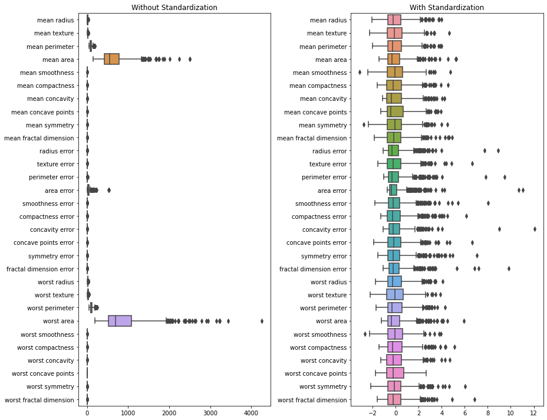

```python
fig, ax = plt.subplots(figsize=(13, 10))

# box plot without standardization
plt.subplot(1, 2, 1)
sns.boxplot(data= cov_data, orient='horizontal')
plt.title('Without Standardization')

# box plot with standardization
plt.subplot(1, 2, 2)
sns.boxplot(data=(cov_data - cov_data.mean()) / cov_data.std(), orient='horizontal')
plt.title('With Standardization')

# show plot
plt.tight_layout()
plt.show()
```

### Tranformation results

The number of principal components is the number of original variables. For example, the breast cancer data at most has 30 principal components. For simple visualization, I plot only the first 15 PCs. The scree plot shows the most apparent turning point between 4th and 5th pc. Choose to retain four PCs allows us to preserve almost 80 % of variance.

```
<module 'matplotlib.pyplot' from 'c:\\Users\\user\\AppData\\Local\\Programs\\Python\\Python310\\lib\\site-packages\\matplotlib\\pyplot.py'>
```

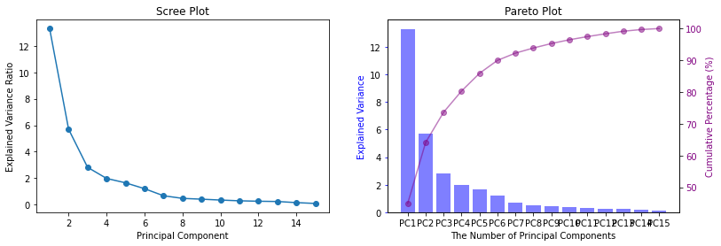

```python
pca_report(cov_data, standardization=1, variables = numeric_cols, numbers = 15, case = 1)
```

### Sources of principal component

Here are the main original variables influence each principal component.

- 1st PC: mean concavity, mean concave points, worst concave points
- 2nd PC: mean fractal dimension, worst fractal dimension, fractal dimension error, mean radius
- 3nd PC: texture error, smoothness error, symmetry error, worst symmetry
- 4th PC: mean texture, worst texture In addition to reducing demensions, we can assign names to these pcs based on original variables contribution. 1st pc can be called "concavity", 2nd pc can be called "dimension", 3rd pc can be called "error", and the last pc can be called "texture".

```python
pca_report(cov_data, standardization=1, variables = numeric_cols, numbers = 15, case = 2)
```

|  | PC1 | PC2 | PC3 | PC4 | PC5 | PC6 | PC7 | PC8 | PC9 | PC10 | PC11 | PC12 | PC13 | PC14 | PC15 |
| --- | --- | --- | --- | --- | --- | --- | --- | --- | --- | --- | --- | --- | --- | --- | --- |
| mean radius | 0.22 | -0.23 | -0.01 | 0.04 | 0.04 | 0.02 | -0.12 | -0.01 | -0.22 | 0.10 | 0.04 | 0.05 | 0.01 | 0.06 | 0.05 |
| mean texture | 0.10 | -0.06 | 0.06 | -0.60 | -0.05 | -0.03 | 0.01 | 0.13 | 0.11 | 0.24 | -0.30 | 0.25 | 0.20 | -0.02 | 0.11 |
| mean perimeter | 0.23 | -0.22 | -0.01 | 0.04 | 0.04 | 0.02 | -0.11 | -0.02 | -0.22 | 0.09 | 0.02 | 0.04 | 0.04 | 0.05 | 0.04 |
| mean area | 0.22 | -0.23 | 0.03 | 0.05 | 0.01 | -0.00 | -0.05 | 0.03 | -0.20 | 0.07 | 0.11 | 0.07 | 0.07 | 0.01 | -0.01 |
| mean smoothness | 0.14 | 0.19 | -0.10 | 0.16 | -0.37 | -0.29 | -0.14 | -0.29 | 0.01 | -0.07 | -0.14 | 0.32 | 0.05 | 0.45 | 0.12 |
| mean compactness | 0.24 | 0.15 | -0.07 | 0.03 | 0.01 | -0.01 | 0.03 | -0.15 | -0.17 | 0.01 | -0.31 | -0.10 | 0.23 | 0.01 | -0.23 |
| mean concavity | 0.26 | 0.06 | 0.00 | 0.02 | 0.09 | -0.01 | -0.11 | -0.07 | 0.04 | -0.14 | 0.12 | 0.07 | 0.39 | -0.19 | 0.13 |
| mean concave points | 0.26 | -0.03 | -0.03 | 0.07 | -0.04 | -0.05 | -0.15 | -0.15 | -0.11 | 0.01 | -0.07 | 0.04 | 0.13 | -0.24 | 0.22 |
| mean symmetry | 0.14 | 0.19 | -0.04 | 0.07 | -0.31 | 0.36 | -0.09 | -0.23 | 0.26 | 0.57 | 0.16 | -0.29 | 0.19 | 0.03 | 0.07 |
| mean fractal dimension | 0.06 | 0.37 | -0.02 | 0.05 | -0.04 | -0.12 | 0.30 | -0.18 | -0.12 | 0.08 | -0.04 | 0.24 | 0.11 | -0.38 | -0.52 |
| radius error | 0.21 | -0.11 | 0.27 | 0.10 | -0.15 | -0.03 | 0.31 | 0.02 | 0.25 | -0.05 | -0.03 | -0.02 | -0.07 | 0.01 | 0.11 |
| texture error | 0.02 | 0.09 | 0.37 | -0.36 | -0.19 | -0.03 | -0.09 | -0.48 | -0.25 | -0.29 | 0.34 | -0.31 | -0.17 | -0.01 | -0.03 |
| perimeter error | 0.21 | -0.09 | 0.27 | 0.09 | -0.12 | 0.00 | 0.31 | -0.01 | 0.23 | -0.11 | -0.17 | -0.10 | -0.04 | -0.05 | 0.01 |
| area error | 0.20 | -0.15 | 0.22 | 0.11 | -0.13 | -0.04 | 0.35 | 0.09 | 0.23 | -0.09 | 0.05 | -0.02 | 0.06 | 0.08 | 0.05 |
| smoothness error | 0.01 | 0.20 | 0.31 | 0.04 | -0.23 | -0.34 | -0.24 | 0.57 | -0.14 | 0.16 | 0.08 | -0.29 | 0.15 | -0.20 | -0.02 |
| compactness error | 0.17 | 0.23 | 0.15 | -0.03 | 0.28 | 0.07 | 0.02 | 0.12 | -0.15 | 0.04 | -0.21 | -0.26 | 0.01 | 0.49 | -0.17 |
| concavity error | 0.15 | 0.20 | 0.18 | 0.00 | 0.35 | 0.06 | -0.21 | 0.06 | 0.36 | -0.14 | 0.35 | 0.25 | 0.16 | 0.13 | -0.25 |
| concave points error | 0.18 | 0.13 | 0.22 | 0.07 | 0.20 | -0.03 | -0.37 | -0.11 | 0.27 | 0.09 | -0.34 | -0.01 | -0.49 | -0.20 | -0.06 |
| symmetry error | 0.04 | 0.18 | 0.29 | 0.04 | -0.25 | 0.49 | -0.08 | 0.22 | -0.30 | -0.32 | -0.19 | 0.32 | 0.01 | -0.05 | 0.11 |
| fractal dimension error | 0.10 | 0.28 | 0.21 | 0.02 | 0.26 | -0.05 | 0.19 | 0.01 | -0.21 | 0.37 | 0.25 | 0.28 | -0.24 | 0.15 | 0.35 |
| worst radius | 0.23 | -0.22 | -0.05 | 0.02 | -0.00 | -0.00 | -0.01 | 0.04 | -0.11 | 0.08 | 0.11 | 0.04 | -0.14 | 0.02 | -0.17 |
| worst texture | 0.10 | -0.05 | -0.04 | -0.63 | -0.09 | -0.05 | 0.01 | 0.04 | 0.10 | 0.03 | 0.01 | 0.08 | -0.08 | 0.05 | -0.10 |
| worst perimeter | 0.24 | -0.20 | -0.05 | 0.01 | 0.01 | 0.01 | -0.00 | 0.03 | -0.11 | 0.05 | 0.05 | -0.01 | -0.10 | 0.01 | -0.18 |
| worst area | 0.22 | -0.22 | -0.01 | 0.03 | -0.03 | -0.03 | 0.07 | 0.08 | -0.08 | 0.07 | 0.18 | 0.05 | -0.10 | -0.01 | -0.31 |
| worst smoothness | 0.13 | 0.17 | -0.26 | 0.02 | -0.32 | -0.37 | -0.11 | 0.21 | 0.11 | -0.13 | 0.14 | 0.06 | -0.21 | 0.16 | -0.05 |
| worst compactness | 0.21 | 0.14 | -0.24 | -0.09 | 0.12 | 0.05 | 0.14 | 0.08 | -0.10 | -0.17 | -0.20 | -0.37 | 0.01 | 0.17 | 0.05 |
| worst concavity | 0.23 | 0.10 | -0.17 | -0.07 | 0.19 | 0.03 | -0.06 | 0.07 | 0.16 | -0.31 | 0.19 | -0.09 | 0.22 | -0.07 | 0.20 |
| worst concave points | 0.25 | -0.01 | -0.17 | 0.01 | 0.04 | -0.03 | -0.17 | -0.04 | 0.06 | -0.08 | -0.12 | -0.07 | -0.25 | -0.28 | 0.17 |
| worst symmetry | 0.12 | 0.14 | -0.27 | -0.04 | -0.24 | 0.50 | -0.02 | 0.23 | 0.06 | -0.03 | 0.16 | 0.04 | -0.26 | 0.01 | -0.14 |
| worst fractal dimension | 0.13 | 0.28 | -0.23 | -0.08 | 0.09 | -0.08 | 0.37 | 0.05 | -0.13 | 0.01 | 0.12 | -0.03 | -0.17 | -0.21 | 0.26 |
| Cumulative Proportion(%) | 44.27 | 63.24 | 72.64 | 79.24 | 84.73 | 88.76 | 91.01 | 92.60 | 93.99 | 95.16 | 96.14 | 97.01 | 97.81 | 98.34 | 98.65 |
| Explained Variance | 13.30 | 5.70 | 2.82 | 1.98 | 1.65 | 1.21 | 0.68 | 0.48 | 0.42 | 0.35 | 0.29 | 0.26 | 0.24 | 0.16 | 0.09 |

### Discrimation of principal components

- 2d scatter plot: Only the 1st PC has ability to draw a more clear division line, while other don't. It appears that 1st PC is a better classifier.

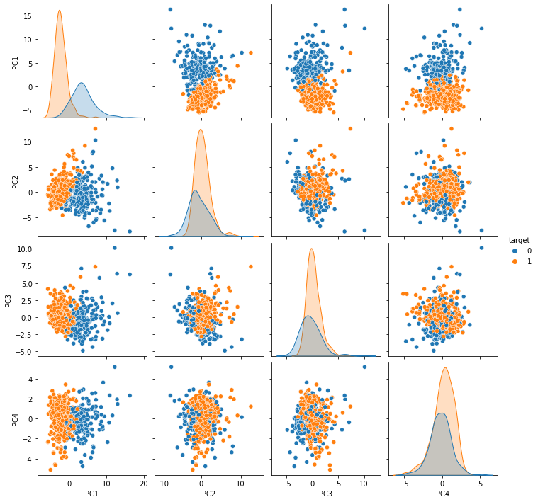

```python
tranformed_data = pca_report(cov_data, standardization=1, variables = variables, numbers = 15, case = 3).iloc[:, :4]
tranformed_data["target"] = breast_data["target"]
tranformed_data.to_excel("transformed_data.xlsx")
# Use the pairplot function to display a scatter plot of all variables in a square plot
sns.pairplot(tranformed_data, hue = "target")
```

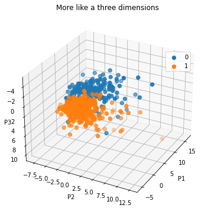

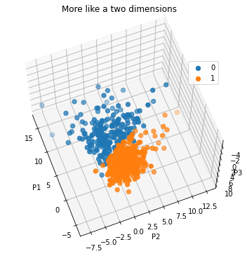

```python
draw_3d(tranformed_data, "target", -152, -28, "More like a three dimensions")
draw_3d(tranformed_data, "target", -117, 21, "More like a two dimensions")
```

### Conclusion

With PCA, we not only can reduce dimensions, but retain the variance of data as well. In the pre-processing stage, correlation and range enables us to estimate how the variables contribute to PC. Then, we perform PCA and subjectively decide the number of PC from scree plot or cumulative variance. At last, even though we lose a part of information, we can extract the most important and simple indexes, which make it convenience for future work or interpretation.